# Trabalho Análise Multivariada II

# Análise de Cluster

## Introdução

A análise de cluster, também conhecida como análise de agrupamento, é uma técnica de mineração. O resultado são grupos que exibem máxima homogeneidade de objetos dentro de grupos e, ao mesmo tempo, máxima heterogeneidade entre os grupos, é uma ferramenta essencial para explorar dados, identificar padrões e segmentar dados em subconjuntos significativos.

## Métodos de Análise de Cluster

Existem vários métodos para realizar a análise de cluster, entre os mais comuns estão:

K-means: Particiona o conjunto de dados em K clusters, onde cada observação pertence ao cluster com a média mais próxima.

1. Hierárquico: Cria uma hierarquia de clusters, que pode ser visualizada como uma árvore ou dendrograma.
2. DBSCAN (Density-Based Spatial Clustering of Applications with Noise): Agrupa pontos que estão próximos uns dos outros com base em uma distância mínima e um número mínimo de pontos em um cluster.
3. Gaussian Mixture Models (GMM): Assume que os dados são gerados a partir de uma mistura de várias distribuições gaussianas.

## Aplicações da Análise de Cluster

A análise de cluster é amplamente utilizada em várias áreas, tais como:

- Marketing: Segmentaçãoo de mercado para identificar grupos de clientes com comportamentos ou necessidades semelhantes.
- Biologia: Classificação de espécies ou genes com base em características observadas.
- Finanças: Identificação de grupos de comportamento de clientes ou risco de crédito.
- Ciência de dados: Redução de dimensionalidade e pré-processamento de dados para algoritmos de aprendizado de máquina.

# Dados

No banco de dados a seguir teremos cidades brasileiras com maiores oportunidades para morar. Para isso teremos as seguintes variaveis:

- ID do município
- Quantidade de pessoas
- Quantidade de pessoas brancas
- Quantidade de pessoas negras
- Quantidade de pessoas indiginas
- Quantidade de pessoas amarelas
- Renda domiciliar média por pessoa
- Quantidade de estabelecimentos de ensino
- Quantidade de estabelecimentos de ensino infantil
- Quantidade de estabelecimentos de ensino fundamental
- Quantidade de estabelecimentos de ensino médio
- Quantidade de estabelecimentos de saúde
- Quantidade de estabelecimentos de saúde de baixa complexidade
- Quantidade de estabelecimentos de saúde de média complexidade
- Quantidade de estabelecimentos de saúde de alta complexidade
- Nome do UF
- Nome do município

### Com isso iremos utilizar uma análise de cluster

```r
dados = read.csv(file = "C:/Users/Amauri/Downloads/dados123.csv")
dados = dados[,c(1:15,17,27)]
```

```
##   id_municipio     quantidade_pessoas quantidade_pessoas_brancas
##  Min.   :1302603   Min.   :  783478   Min.   : 288423
##  1st Qu.:2560730   1st Qu.:  972015   1st Qu.: 390364
##  Median :3303130   Median : 1374893   Median : 625232
##  Mean   :3270021   Mean   : 2182026   Mean   :1069836
##  3rd Qu.:3689456   3rd Qu.: 2365376   3rd Qu.:1072320
##  Max.   :5300108   Max.   :11039920   Max.   :6696107
##  quantidade_pessoas_negras quantidade_pessoas_indigenas
##  Min.   : 270940           Min.   :  679
##  1st Qu.: 494254           1st Qu.: 1514
##  Median : 667062           Median : 2493
##  Mean   :1059175           Mean   : 3236
##  3rd Qu.:1306325           3rd Qu.: 4016
##  Max.   :3975400           Max.   :11580
##  quantidade_pessoas_amarelas renda_domiciliar_pc
##  Min.   :  3618              Min.   : 410.6
##  1st Qu.: 10362              1st Qu.: 621.2
##  Median : 14796              Median : 802.5
##  Mean   : 29804              Mean   : 826.8
##  3rd Qu.: 26068              3rd Qu.:1070.0
##  Max.   :243921              Max.   :1272.7
##  quantidade_estabelecimentos_ensino quantidade_estabelecimentos_ensino_infantil
##  Min.   : 186.0                     Min.   : 57.0
##  1st Qu.: 289.2                     1st Qu.:101.8
##  Median : 396.0                     Median :185.5
##  Mean   : 593.4                     Mean   :244.2
##  3rd Qu.: 582.0                     3rd Qu.:234.2
##  Max.   :2707.0                     Max.   :949.0
##  quantidade_estabelecimentos_ensino_fundamental
##  Min.   : 153.0
##  1st Qu.: 203.5
##  Median : 277.0
##  Mean   : 390.1
##  3rd Qu.: 394.8
##  Max.   :1583.0
##  quantidade_estabelecimentos_ensino_medio quantidade_estabelecimentos_saude
##  Min.   : 54.0                            Min.   : 86.0
##  1st Qu.: 82.5                            1st Qu.:137.8
##  Median :105.0                            Median :222.5
##  Mean   :145.5                            Mean   :245.6
```

[output cut: 15 more lines]

```
##  Max.   :840.0
##  quantidade_estabelecimentos_saude_alta_coplexidade   Nome_UF
##  Min.   : 10.00                                     Length:20
##  1st Qu.: 21.50                                     Class :character
##  Median : 32.00                                     Mode  :character
##  Mean   : 41.15
##  3rd Qu.: 49.00
##  Max.   :132.00
##  Nome_Município
##  Length:20
##  Class :character
##  Mode  :character
##
##
##
```

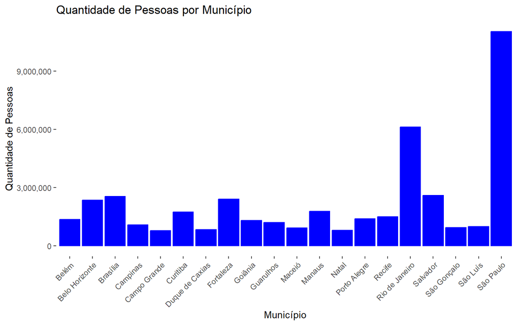

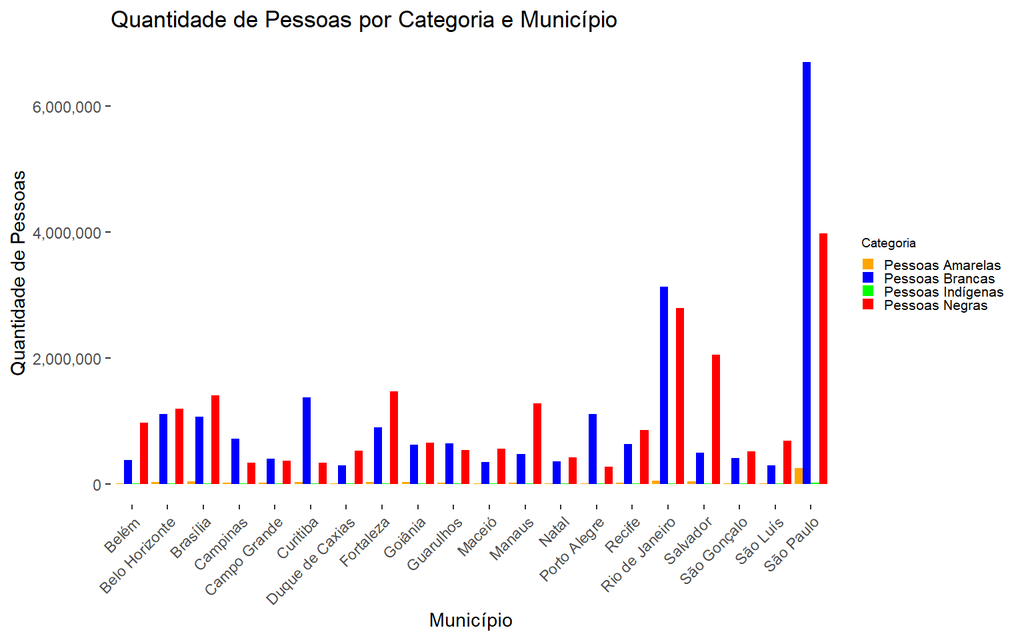

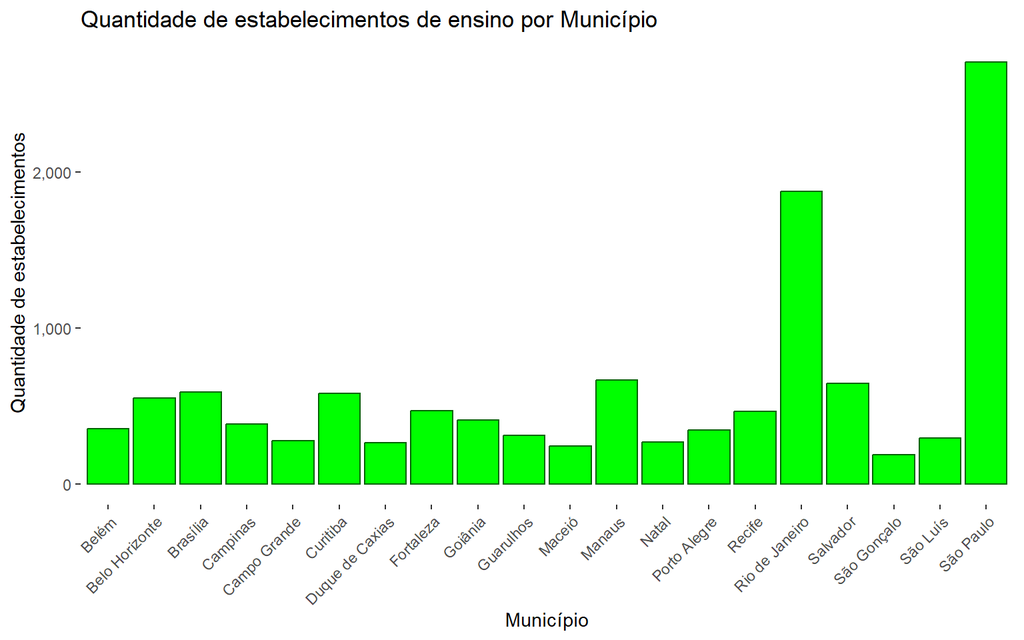

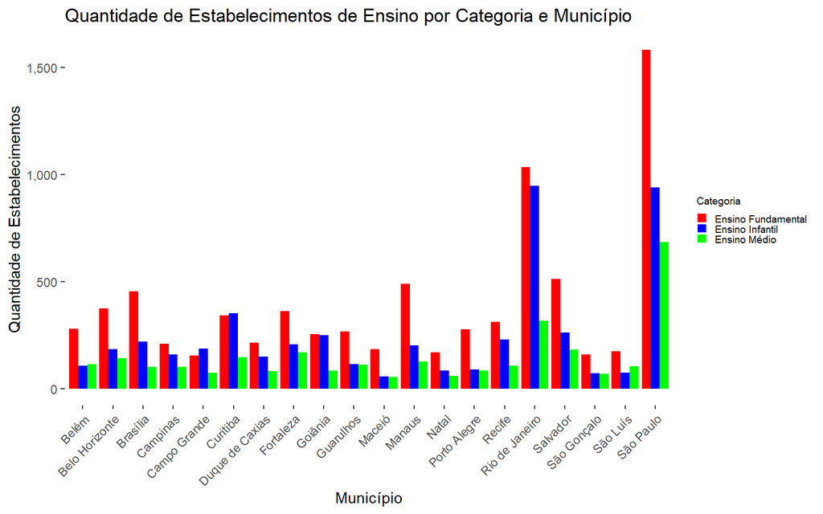

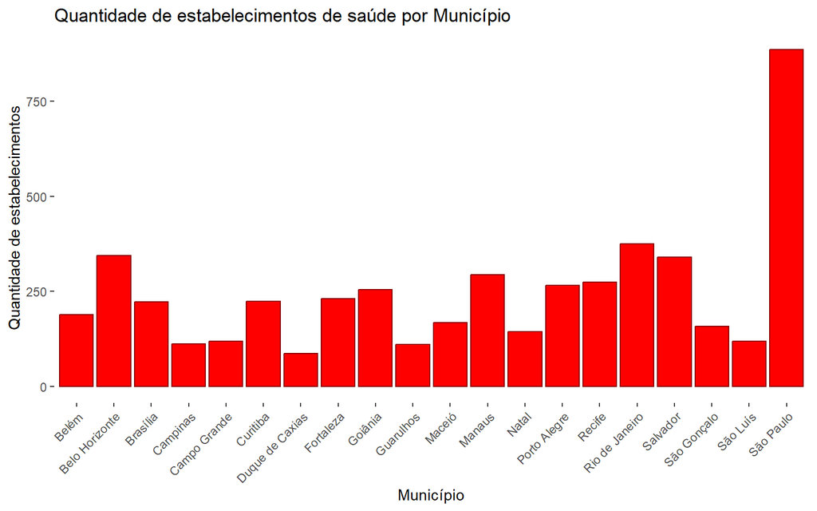

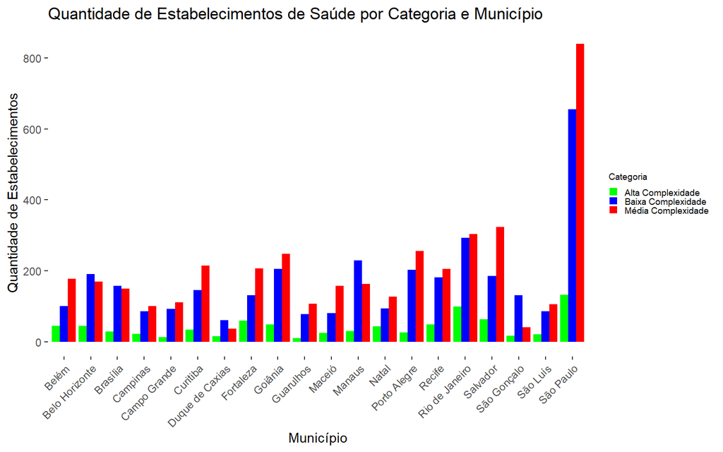

# Análise de clusters

## Número optimo de cluster

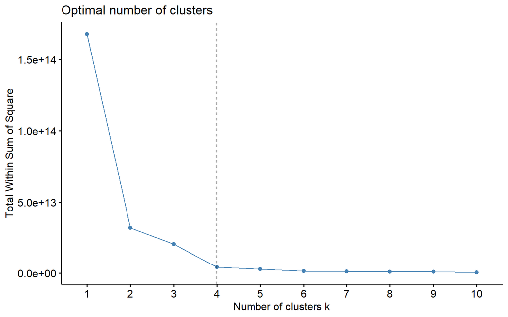

```
## Too few points to calculate an ellipse
## Too few points to calculate an ellipse
```

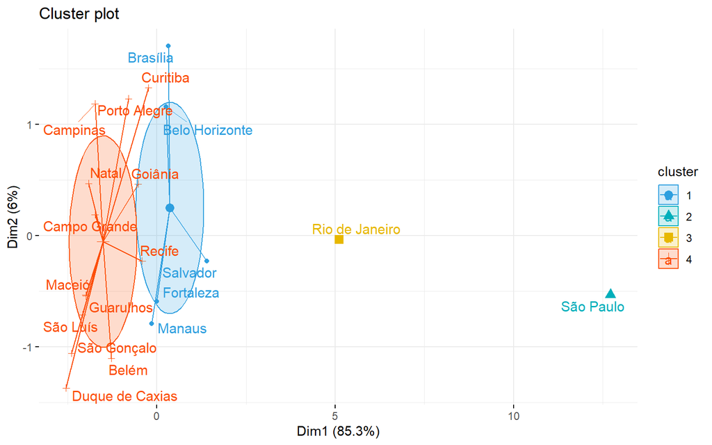

## Com três clusters:

```r
cluster2 <- kmeans(dados, 3, nstart = 20)
```

```
## Too few points to calculate an ellipse
```

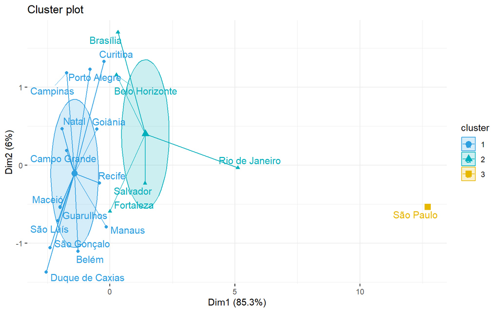

```r
fviz_cluster(cluster2, data = dados,
             palette = c("#2E9FDF", "#00AFBB", "#E7B800"),
             ellipse.type = "euclid",
             star.plot = TRUE,
             repel = TRUE,
             ggtheme = theme_minimal())
```

# Método Hierárquico Aglomerativo:

## Matriz de similaridade

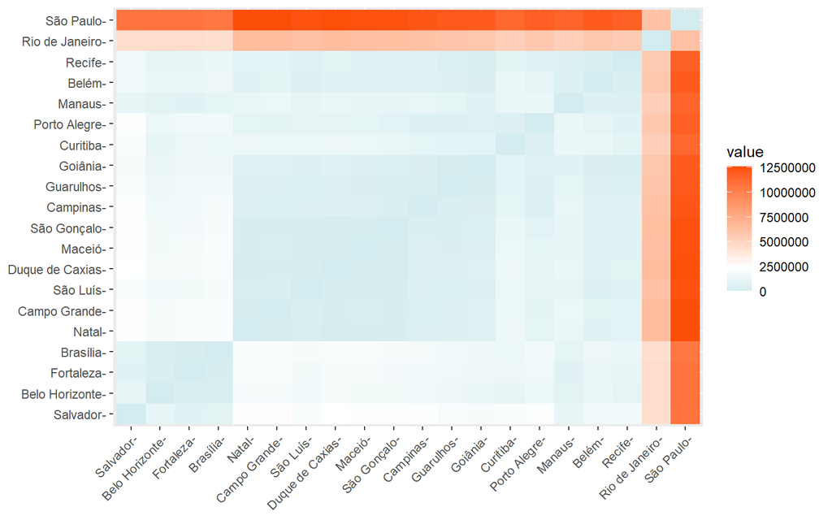

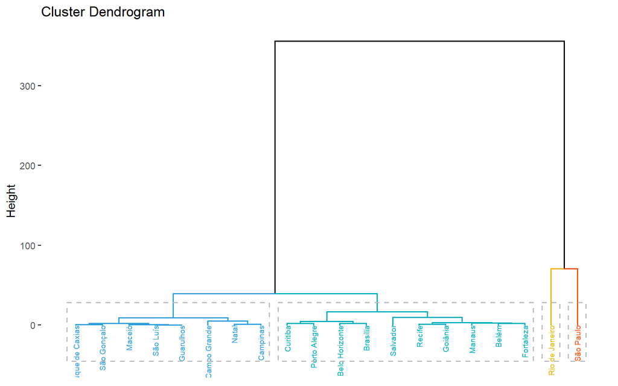

## Com Três clusters

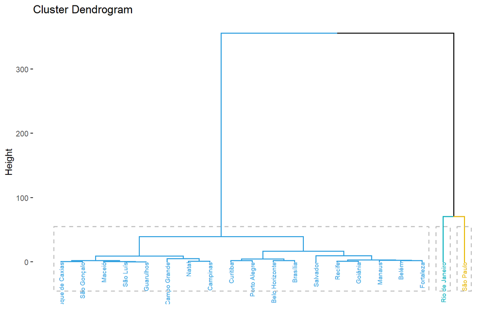

# comparação sobre o tempo dos dois métodos utilizados:

```r
print(tempos)
```

```
## [1] 0.11 0.78
```

# Referências:

Nesta analise foram utilizados principalmente os materiais mostrados em sala de aula e artigos do rpubs(https://rpubs.com/LeMaria/cluster), algumas dúvidas sobre os códigos e definições também foram sanadas pelo Chatgpt.